**Convolutional Neural Networks (CNN)**

By Prof. Seungchul Lee  
http://iai.postech.ac.kr/  
Industrial AI Lab at POSTECH

Table of Contents

# 1. Convolution in 2D

**Filter (or Kernel)**

- Modify or enhance an image by filtering
- Filter images to emphasize certain features or remove other features
- Filtering includes smoothing, sharpening and edge enhancement
- Discrete convolution can be viewed as element-wise multiplication by a matrix

[figure not shown]

# 2. Convolutional Neural Networks (CNN)

## 2.1. Motivation: Learning Visual Features

The bird occupies a local area and looks the same in different parts of an image. We should construct neural networks which exploit these properties.

[figure not shown]

- ANN structure for object detecion in image
  - does not seem the best
  - did not make use of the fact that we are dealing with images
  - Spatial organization of the input is destroyed by flattening

[figure not shown]

- Convolution Mask + Neural Network
  - Utilize spatial information of the image

[figure not shown]

- **Locality**: objects tend to have a local spatial support
  - fully and convolutionally connected layer $\rightarrow$ locally and convolutionally connected layer

[figure not shown]

- **Translation invariance**: object appearance is independent of location
  - Weight sharing: untis connected to different locations have the same weights
  - We are not designing the kernel, but are learning the kernel from data
  - *i.e.* We are learning visual feature extractor from data

[figure not shown]

```python
%%html
<center><iframe src="https://www.youtube.com/embed/0Hr5YwUUhr0?rel=0"
width="560" height="315" frameborder="0" allowfullscreen></iframe></center>
```

[video not shown]

**Question: Object Size?**

[figure not shown]

## 2.2. Convolutional Operator

**Matrix multiplication of ANN**

- Every output unit interacts with every interacts unit

[figure not shown]

**Convolution of CNN**

- Local connectivity
- Weight sharing
- Typically have sparse interactions

[figure not shown]

**(Deep) Artificial Neural Networks**

- Universal function approximator
  - Linear connected networks
  - Simple nonlinear neurons
- Hidden layers
  - Autonomous feature learning

[figure not shown]

**(Deep) Convolutional Neural Networks**

- Structure
  - Weight sharing
  - Local connectivity
- Optimization
  - Smaller searching space

[figure not shown]

- Convolutional Neural Networks
  - Simply neural networks that use the convolution in place of general matrix multiplication in at least one of their layers

```python
%%html
<center><iframe src="https://www.youtube.com/embed/ISHGyvsT0QY?rel=0"
width="560" height="315" frameborder="0" allowfullscreen></iframe></center>
```

[video not shown]

- Multiple kernels

[figure not shown]

- Multiple channels

[figure not shown]

- Convolution Shape
  - Activation or feature maps
    - input $(W^i, H^i, C)$
    - output $(W^o, H^o, D)$
  - Kernel of filter $(w, h, C, D)$
    - $w \times h$ kernel size
    - $C$ input channels
    - $D$ output channels
  - Number of parameters (due to bias)
    - $(w \times h \times \times C + 1) \times D$

[figure not shown]

- The kernel is not swiped across channels, just across rows and columns.
- Note that a convolution preserves the signal support structure.
- A 1D signal is converted into a 1D signal, a 2D signal into a 2D, and neighboring parts of the input signal inﬂuence neighboring parts of the output signal.
- A 3D convolution can be used if the channel index has some metric meaning, such as time for a series of grayscale video frames. Otherwise swiping across channels makes no sense.
- We usually refer to one of the channels generated by a convolution layer as an activation map.
- The sub-area of an input map that inﬂuences a component of the output as the receptive ﬁeld of the latter.
- In the context of convolutional networks, a standard linear layer is called a fully connected layer since every input inﬂuences every output.
- (You can view an animated demo on [this](http://cs231n.github.io/convolutional-networks/) page.)

## 2.3 Stride and Padding

- Strides: increment step size for the convolution operator
  - Reduces the size of the output map
- No stride and no padding

[figure not shown]

- Stride example with kernel size 3×3 and a stride of 2

[figure not shown]

- Padding: artificially fill borders of image
  - Useful to keep spatial dimension constant across filters
  - Useful with strides and large receptive fields
  - Usually fill with 0s

[figure not shown]

- More [convolution arithmetic](https://github.com/vdumoulin/conv_arithmetic)

```python
%%html
<center><iframe src="https://www.youtube.com/embed/W4xtf8LTz1c?rel=0"
width="560" height="315" frameborder="0" allowfullscreen></iframe></center>
```

[video not shown]

## 2.4. Nonlinear Activation Function

[figure not shown]

## 2.5. Pooling

- Compute a maximum value in a sliding window (max pooling)
  - Reduce spatial resolution for faster computation
  - Achieve invariance to any permutation inside one of the cell

[figure not shown]

- Pooling size : $2\times2$ for example

[figure not shown]

- Pooling in multiple channel

[figure not shown]

- Max pooling introduces invariances

[figure not shown]

```python
%%html
<center><iframe src="https://www.youtube.com/embed/FG7M9tWH2nQ?rel=0"
width="560" height="315" frameborder="0" allowfullscreen></iframe></center>
```

[video not shown]

## 2.6. Inside the Convolution Layer

- First, the layer performs several convolutions to produce a set of linear activations
- Second, each linear activation is running through a nonlinear activation function
- Third, use pooling to modify the output of the layer further

[figure not shown]

## 2.7. CNN for Classification

- CONV and POOL layers output high-level features of input
- Fully connected layer uses these features for classifying input image
- Express output as probability of image belonging to a particular class

[figure not shown]

```python
%%html
<center><iframe src="https://www.youtube.com/embed/utOv-BKI_vo?rel=0"
width="560" height="315" frameborder="0" allowfullscreen></iframe></center>
```

[video not shown]

ConvNet performs better with the same number of parameters, due to its use of a prior knowledge about iamges.

# 3. Lab: CNN with TensorFlow

- MNIST example
- To classify handwritten digits

[figure not shown]

```python
%%html
<center><iframe src="https://www.youtube.com/embed/z6k_RMKExlQ?start=5150&end=6132?rel=0"
width="560" height="315" frameborder="0" allowfullscreen></iframe></center>
```

[video not shown]

## 3.1. Import Library and Load MNIST Data

```python
# Import Library
import numpy as np
import matplotlib.pyplot as plt
import tensorflow as tf

from tensorflow.examples.tutorials.mnist import input_data
mnist = input_data.read_data_sets("MNIST_data/", one_hot=True)
```

[output not shown]

## 3.2. Define the CNN Structure

**Convolution layers**

- First, the layer performs several convolutions to produce a set of linear activations
- Second, each linear activation is running through a nonlinear activation function
- Third, use pooling to modify the output of the layer further

**Fully connected layers**

- Simple multi-layer perceptrons

[figure not shown]

```python
# input layer
input_h = 28 # Input height
input_w = 28 # Input width
input_ch = 1 # Input channel : Gray scale
# (None, 28, 28, 1)

# First convolution layer
k1_h = 3
k1_w = 3
k1_ch = 32
p1_h = 2
p1_w = 2
# (None, 14, 14 ,32)

# Second convolution layer
k2_h = 3
k2_w = 3
k2_ch = 64
p2_h = 2
p2_w = 2
# (None, 7, 7 ,64)

## Fully connected
# Flatten the features -> (None, 7*7*64)
conv_result_size = int((28/(2*2)) * (28/(2*2)) * k2_ch)
n_hidden = 100
n_output = 10
```

## 3.3. Define Weights, Biases and Placeholder

- Define parameters based on predefined layer size
- Initialize with normal distribution with $\mu = 0$ and $\sigma = 0.1$

```python
# kernel size: [kernel_height, kernel_width, input_ch, output_ch]
weights = {
    'conv1' : tf.Variable(tf.random_normal([k1_h, k1_w, input_ch, k1_ch], stddev = 0.1)),
    'conv2' : tf.Variable(tf.random_normal([k2_h, k2_w, k1_ch, k2_ch], stddev = 0.1)),
    'hidden' : tf.Variable(tf.random_normal([conv_result_size, n_hidden], stddev = 0.1)),
    'output' : tf.Variable(tf.random_normal([n_hidden, n_output], stddev = 0.1))
}

# bias size: [output_ch] or [neuron_size]
biases = {
    'conv1' : tf.Variable(tf.random_normal([k1_ch], stddev = 0.1)),
    'conv2' : tf.Variable(tf.random_normal([k2_ch], stddev = 0.1)),
    'hidden' : tf.Variable(tf.random_normal([n_hidden], stddev = 0.1)),
    'output' : tf.Variable(tf.random_normal([n_output], stddev = 0.1))
}

# input layer: [batch_size, image_height, image_width, channels]
# output layer: [batch_size, class_size]
x = tf.placeholder(tf.float32, [None, input_h, input_w, input_ch])
y = tf.placeholder(tf.float32, [None, n_output])
```

## 3.4. Build a CNN Model

**First, the layer performs several convolutions to produce a set of linear activations**

[figure not shown]

- Filter size : $3\times3$
- Stride : The stride of the sliding window for each dimension of input
- Padding : Allow us to control the kernel width and the size of the output independently
  - `'SAME'` : zero padding
  - `'VALID'` : No padding

**Second, each linear activation is running through a nonlinear activation function**

[figure not shown]

**Third, use a pooling to modify the output of the layer further**

- Compute a maximum value in a sliding window (max pooling)

[figure not shown]

- Pooling size : $2\times2$

**Dense (fully connected) layer**

- Input is typically in a form of flattened features
- Then, apply `softmax` to multiclass classification problems
- The output of the softmax function is equivalent to a categorical probability distribution, it tells you the probability that any of the classes are true.

[figure not shown]

```python
# [batch, height, width, channels]

def net(x, weights, biases):
    # First convolution layer
    conv1 = tf.nn.conv2d(x,
                         weights['conv1'],
                         strides= [1, 1, 1, 1],
                         padding = 'SAME')
    conv1 = tf.nn.relu(tf.add(conv1, biases['conv1']))
    maxp1 = tf.nn.max_pool(conv1,
                           ksize = [1, p1_h, p1_w, 1],
                           strides = [1, p1_h, p1_w, 1],
                           padding = 'VALID')

    # Second convolution layer
    conv2 = tf.nn.conv2d(maxp1,
                         weights['conv2'],
                         strides= [1, 1, 1, 1],
                         padding = 'SAME')
    conv2 = tf.nn.relu(tf.add(conv2, biases['conv2']))
    maxp2 = tf.nn.max_pool(conv2,
                           ksize = [1, p2_h, p2_w, 1],
                           strides = [1, p2_h, p2_w, 1],
                           padding = 'VALID')

    maxp2_flatten = tf.reshape(maxp2, [-1, conv_result_size])

    # Fully connected
    hidden = tf.add(tf.matmul(maxp2_flatten, weights['hidden']), biases['hidden'])
    hidden = tf.nn.relu(hidden)
    output = tf.add(tf.matmul(hidden, weights['output']), biases['output'])

    return output
```

## 3.5. Define Loss, and Optimizer

**Loss**

- Classification: Cross entropy
  - Equivalent to apply logistic regression

$$ -\frac{1}{m}\sum_{i=1}^{m}y^{(i)}\log(h_{\theta}\left(x^{(i)}\right)) + (1-y^{(i)})\log(1-h_{\theta}\left(x^{(i)}\right)) $$

**Optimizer**

- GradientDescentOptimizer
- AdamOptimizer: the most popular optimizer

```python
LR = 0.0001

pred = net(x, weights, biases)
loss = tf.nn.softmax_cross_entropy_with_logits(labels = y, logits = pred)
loss = tf.reduce_mean(loss)

optm = tf.train.AdamOptimizer(LR).minimize(loss)
```

[output not shown]

## 3.6. Optimize

- Define hyper parameters for training CNN
  - `n_batch` : mini-batch size for stochastic gradient descent
  - `n_iter` : the number of training steps
  - `n_prt` : print loss for every `n_prt` iteration

```
Iter : 0
Cost : 2.3602051734924316
Iter : 250
Cost : 0.7490301728248596
Iter : 500
Cost : 0.250809907913208
Iter : 750
Cost : 0.11436524242162704
Iter : 1000
Cost : 0.22484460473060608
Iter : 1250
Cost : 0.21168747544288635
Iter : 1500
Cost : 0.23444479703903198
Iter : 1750
Cost : 0.07206088304519653
Iter : 2000
Cost : 0.1176096722483635
Iter : 2250
Cost : 0.22551988065242767
```

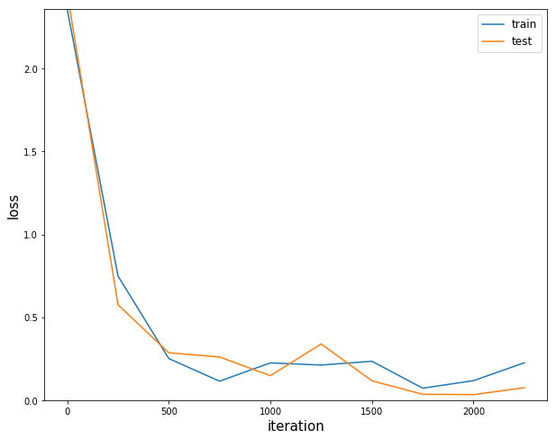

```python
n_batch = 50
n_iter = 2500
n_prt = 250

sess = tf.Session()
init = tf.global_variables_initializer()
sess.run(init)

loss_record_train = []
loss_record_test = []
for epoch in range(n_iter):
    train_x, train_y = mnist.train.next_batch(n_batch)
    train_x = np.reshape(train_x, [-1, input_h, input_w, input_ch])
    sess.run(optm, feed_dict = {x: train_x,  y: train_y})

    if epoch % n_prt == 0:
        test_x, test_y = mnist.test.next_batch(n_batch)
        test_x = np.reshape(test_x, [-1, input_h, input_w, input_ch])
        c1 = sess.run(loss, feed_dict = {x: train_x, y: train_y})
        c2 = sess.run(loss, feed_dict = {x: test_x, y: test_y})
        loss_record_train.append(c1)
        loss_record_test.append(c2)
        print ("Iter : {}".format(epoch))
        print ("Cost : {}".format(c1))

plt.figure(figsize=(10,8))
plt.plot(np.arange(len(loss_record_train))*n_prt, loss_record_train, label = 'train')
plt.plot(np.arange(len(loss_record_test))*n_prt, loss_record_test, label = 'test')
plt.xlabel('iteration', fontsize = 15)
plt.ylabel('loss', fontsize = 15)
plt.legend(fontsize = 12)
plt.ylim([0, np.max(loss_record_train)])
plt.show()
```

## 3.7. Test or Evaluate

```python
test_x, test_y = mnist.test.next_batch(100)

my_pred = sess.run(pred, feed_dict = {x: test_x.reshape(-1, 28, 28, 1)})
my_pred = np.argmax(my_pred, axis = 1)

labels = np.argmax(test_y, axis = 1)

accr = np.mean(np.equal(my_pred, labels))
print("Accuracy : {}%".format(accr*100))
```

```
Accuracy : 97.0%
```

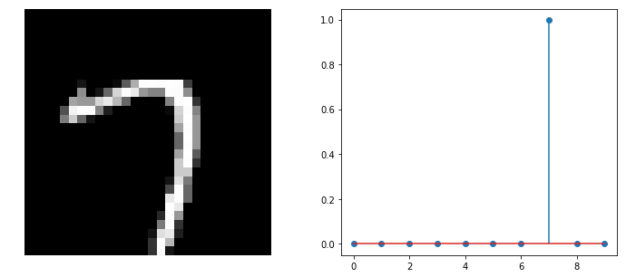

```
Prediction : 7
Probability : [0. 0. 0. 0. 0. 0. 0. 1. 0. 0.]
```

```python
test_x, test_y = mnist.test.next_batch(1)
logits = sess.run(tf.nn.softmax(pred), feed_dict = {x: test_x.reshape(-1, 28, 28, 1)})
predict = np.argmax(logits)

plt.figure(figsize = (12,5))
plt.subplot(1,2,1)
plt.imshow(test_x.reshape(28, 28), 'gray')
plt.axis('off')
plt.subplot(1,2,2)
plt.stem(logits.ravel())
plt.show()

np.set_printoptions(precision = 2, suppress = True)
print('Prediction : {}'.format(predict))
print('Probability : {}'.format(logits.ravel()))
```

## 3.8. CNN Implemented in an Embedded System

```python
%%html
<center><iframe src="https://www.youtube.com/embed/baPLXhjslL8?rel=0"
width="560" height="315" frameborder="0" allowfullscreen></iframe></center>
```

[video not shown]

# 4. Other Tutorials

- Neural Network 3D Simulation

```python
%%html
<center><iframe src="https://www.youtube.com/embed/3JQ3hYko51Y?rel=0"
width="560" height="315" frameborder="0" allowfullscreen></iframe></center>
```

[video not shown]

```python
%%html
<center><iframe src="https://www.youtube.com/embed/FTr3n7uBIuE?rel=0"
width="560" height="315" frameborder="0" allowfullscreen></iframe></center>
```

[video not shown]

- CS231n Convolutional Neural Networks for Visual Recognition at Stanford Univ.
  - http://cs231n.github.io/convolutional-networks/

```python
%%html
<center><iframe src="https://www.youtube.com/embed/LxfUGhug-iQ?rel=0"
width="560" height="315" frameborder="0" allowfullscreen></iframe></center>
```

[video not shown]

```python
%%html
<center><iframe src="https://www.youtube.com/embed/bNb2fEVKeEo?rel=0"
width="560" height="315" frameborder="0" allowfullscreen></iframe></center>
```

[video not shown]

- MIT 6.S191
  - http://introtodeeplearning.com/

```python
%%html
<center><iframe src="https://www.youtube.com/embed/NVH8EYPHi30?rel=0"
width="560" height="315" frameborder="0" allowfullscreen></iframe></center>
```

[video not shown]

```python
%%javascript
$.getScript('https://kmahelona.github.io/ipython_notebook_goodies/ipython_notebook_toc.js')
```